# report data analysis for zip data

Chiho Taniguchi

2023-02-26

# Data construction

We use data defining the market as first three digits of the zipcode (zip_three) and restrict data to the general establishments only for analysis. After dropping establishments which have missing either of wage / fee / zip_three data and creating log transformed wage / fee, we create N_zip_t and dummy variables indicating the N_zip_t. N_zip_t and dummy variables are explained in detail later.

# Descriptive statistics

## wage (wage_{it})

```
##    Min. 1st Qu.  Median    Mean 3rd Qu.    Max.
##  0.0800  0.8854  1.0147  1.0775  1.2145  6.8932
```

## fee (fee_{it})

```
##    Min. 1st Qu.  Median    Mean 3rd Qu.    Max.
##   0.120   1.263   1.466   1.561   1.771  18.234
```

## N_zip_t

N_zip_t is a variable that indicates the number of general establishments present in the market defined first three digits of zip code (zip) in year t.

|  | N_zip_t |
| --- | --- |
| 5% | 10.35 |
| 10% | 19.70 |
| 25% | 47.75 |
| 50% | 95.00 |
| 75% | 181.25 |
| 100% | 491.00 |

### Show historgam

On the left is the distribution of N_zip_t, without duplicates, and on the right is the distribution of N_zip_t, using all data (allowing duplicates).

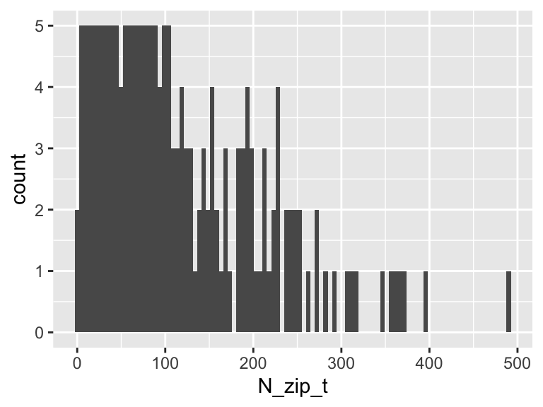

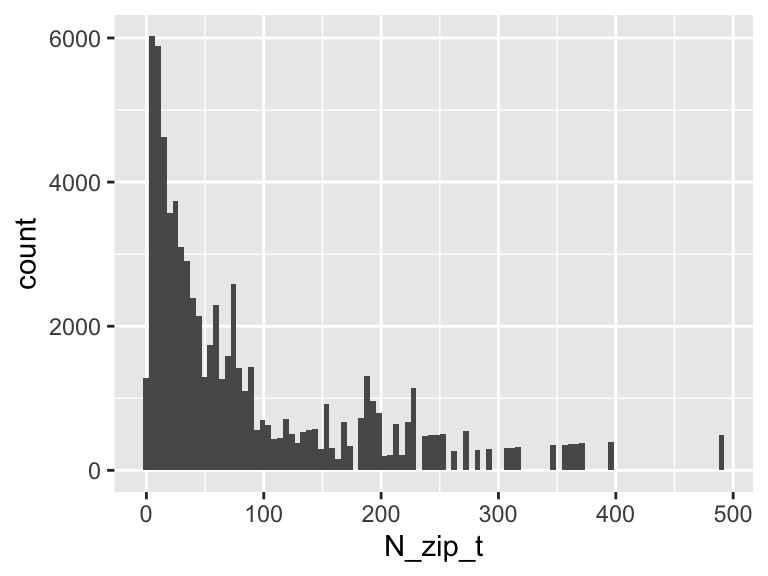

# Analyze different N_zip_t

Analyze the impact of the number of general establishments in each market (zip) on the log transformed wage / fee:

$$

Y_{ijt} = N_{jt} + c_{j} + c_{t} + u_{ijt},\ Y_{ijt} = N_{jt} + c_{i} + c_{t} + u_{ijt},\ Y_{ijt} = N_{jt} + c_{j} + c_{i} + c_{t} + u_{ijt}.

$$

$i$: Establishment, $j$: zip three area, $t$: Year  
$Y_{ijt}$: $\log{(wage_{ijt})}$, $\log{(fee_{ijt})}$

We also analyze N_zip_t is divided by the number after N_zip_t.

## Analyze for N_zip_t

|  | log(fee) | log(fee) | log(fee) | log(wage) | log(wage) | log(wage) |
| --- | --- | --- | --- | --- | --- | --- |
| N_zip_t | 0.000* | 0.000*** | 0.000* | 0.000+ | 0.000*** | 0.000+ |
|  | [0.000, 0.000] | [0.000, 0.000] | [0.000, 0.000] | [0.000, 0.000] | [0.000, 0.000] | [0.000, 0.000] |
| j_FE | Y | N | Y | Y | N | Y |
| t_FE | Y | Y | Y | Y | Y | Y |
| i_FE | N | Y | Y | N | Y | Y |
| Num.Obs. | 72954 | 72952 | 72952 | 72954 | 72952 | 72952 |
| R2 | 0.235 | 0.507 | 0.597 | 0.258 | 0.510 | 0.605 |
| R2 Adj. | 0.226 | 0.461 | 0.554 | 0.249 | 0.464 | 0.563 |
| RMSE | 0.34 | 0.27 | 0.25 | 0.30 | 0.25 | 0.22 |

+ p < 0.1, * p < 0.05, ** p < 0.01, *** p < 0.001

## Analyze for N_zip_t_10

|  | log(fee) | log(fee) | log(fee) | log(wage) | log(wage) | log(wage) |
| --- | --- | --- | --- | --- | --- | --- |
| N_zip_t_10 | 0.002* | 0.004*** | 0.002* | 0.001+ | 0.004*** | 0.001+ |
|  | [0.000, 0.004] | [0.004, 0.004] | [0.000, 0.003] | [0.000, 0.003] | [0.004, 0.004] | [0.000, 0.002] |
| j_FE | Y | N | Y | Y | N | Y |
| t_FE | Y | Y | Y | Y | Y | Y |
| i_FE | N | Y | Y | N | Y | Y |
| Num.Obs. | 72954 | 72952 | 72952 | 72954 | 72952 | 72952 |
| R2 | 0.235 | 0.507 | 0.597 | 0.258 | 0.510 | 0.605 |
| R2 Adj. | 0.226 | 0.461 | 0.554 | 0.249 | 0.464 | 0.563 |
| RMSE | 0.34 | 0.27 | 0.25 | 0.30 | 0.25 | 0.22 |

+ p < 0.1, * p < 0.05, ** p < 0.01, *** p < 0.001

## Analyze for N_zip_t_100

|  | log(fee) | log(fee) | log(fee) | log(wage) | log(wage) | log(wage) |
| --- | --- | --- | --- | --- | --- | --- |
| N_zip_t_100 | 0.020* | 0.039*** | 0.015* | 0.014+ | 0.038*** | 0.011+ |
|  | [0.004, 0.037] | [0.036, 0.042] | [0.002, 0.029] | [0.000, 0.028] | [0.035, 0.040] | [0.000, 0.023] |
| j_FE | Y | N | Y | Y | N | Y |
| t_FE | Y | Y | Y | Y | Y | Y |
| i_FE | N | Y | Y | N | Y | Y |
| Num.Obs. | 72954 | 72952 | 72952 | 72954 | 72952 | 72952 |
| R2 | 0.235 | 0.507 | 0.597 | 0.258 | 0.510 | 0.605 |
| R2 Adj. | 0.226 | 0.461 | 0.554 | 0.249 | 0.464 | 0.563 |
| RMSE | 0.34 | 0.27 | 0.25 | 0.30 | 0.25 | 0.22 |

+ p < 0.1, * p < 0.05, ** p < 0.01, *** p < 0.001

## Analyze for N_zip_t_1000

|  | log(fee) | log(fee) | log(fee) | log(wage) | log(wage) | log(wage) |
| --- | --- | --- | --- | --- | --- | --- |
| N_zip_t_1000 | 0.203* | 0.388*** | 0.152* | 0.140+ | 0.378*** | 0.115+ |
|  | [0.041, 0.366] | [0.359, 0.417] | [0.018, 0.286] | [−0.004, 0.284] | [0.352, 0.404] | [−0.004, 0.234] |
| j_FE | Y | N | Y | Y | N | Y |
| t_FE | Y | Y | Y | Y | Y | Y |
| i_FE | N | Y | Y | N | Y | Y |
| Num.Obs. | 72954 | 72952 | 72952 | 72954 | 72952 | 72952 |
| R2 | 0.235 | 0.507 | 0.597 | 0.258 | 0.510 | 0.605 |
| R2 Adj. | 0.226 | 0.461 | 0.554 | 0.249 | 0.464 | 0.563 |
| RMSE | 0.34 | 0.27 | 0.25 | 0.30 | 0.25 | 0.22 |

+ p < 0.1, * p < 0.05, ** p < 0.01, *** p < 0.001

## Analyze for N_zip_t_10000

|  | log(fee) | log(fee) | log(fee) | log(wage) | log(wage) | log(wage) |
| --- | --- | --- | --- | --- | --- | --- |
| N_zip_t_10000 | 2.032* | 3.879*** | 1.522* | 1.399+ | 3.779*** | 1.146+ |
|  | [0.407, 3.657] | [3.589, 4.169] | [0.185, 2.860] | [−0.041, 2.839] | [3.519, 4.039] | [−0.044, 2.336] |
| j_FE | Y | N | Y | Y | N | Y |
| t_FE | Y | Y | Y | Y | Y | Y |
| i_FE | N | Y | Y | N | Y | Y |
| Num.Obs. | 72954 | 72952 | 72952 | 72954 | 72952 | 72952 |
| R2 | 0.235 | 0.507 | 0.597 | 0.258 | 0.510 | 0.605 |
| R2 Adj. | 0.226 | 0.461 | 0.554 | 0.249 | 0.464 | 0.563 |
| RMSE | 0.34 | 0.27 | 0.25 | 0.30 | 0.25 | 0.22 |

+ p < 0.1, * p < 0.05, ** p < 0.01, *** p < 0.001

## Analyze for N_zip_t_100000

|  | log(fee) | log(fee) | log(fee) | log(wage) | log(wage) | log(wage) |
| --- | --- | --- | --- | --- | --- | --- |
| N_zip_t_100000 | 20.323* | 38.792*** | 15.224* | 13.991+ | 37.793*** | 11.459+ |
|  | [4.071, 36.574] | [35.892, 41.691] | [1.846, 28.602] | [−0.405, 28.387] | [35.192, 40.393] | [−0.444, 23.362] |
| j_FE | Y | N | Y | Y | N | Y |
| t_FE | Y | Y | Y | Y | Y | Y |
| i_FE | N | Y | Y | N | Y | Y |
| Num.Obs. | 72954 | 72952 | 72952 | 72954 | 72952 | 72952 |
| R2 | 0.235 | 0.507 | 0.597 | 0.258 | 0.510 | 0.605 |
| R2 Adj. | 0.226 | 0.461 | 0.554 | 0.249 | 0.464 | 0.563 |
| RMSE | 0.34 | 0.27 | 0.25 | 0.30 | 0.25 | 0.22 |

+ p < 0.1, * p < 0.05, ** p < 0.01, *** p < 0.001

# Analyze for N_zip_t with categorical dummy variables

Analyze the impact of the marginally increase in the number of general establishments in each market (zip) on the log transformed wage / fee:

$$

$$

$i$: Establishment, $j$: zip three area, $t$: Year  
$Y_{ijt}$: $\log{(wage_{ijt})}$, $\log{(fee_{ijt})}$

## Categorical variables per quantile (20)

We create categorical dummy variables as follows.

D_20 : Dummy variable that takes 1 when N_zip_t is less than the 20th percentile value  
D_40 : Dummy variable that takes 1 when N_zip_t is greater than or equal to the 20th percentile value and less than or equal to the 40th percentile value  
D_60 : Dummy variable that takes 1 when N_zip_t is greater than the 40th percentile value and less than the 60th percentile value  
D_80 : Dummy variable that takes 1 when N_zip_t is above the 60th percentile value and below the 80th percentile value  
D_100 : Dummy variable that takes 1 when N_zip_t is greater than or equal to the 80th percentile value

|  | log(fee) | log(fee) | log(fee) | log(wage) | log(wage) | log(wage) |
| --- | --- | --- | --- | --- | --- | --- |
| D_40 | 0.020+ | 0.054*** | 0.008 | 0.014 | 0.054*** | 0.003 |
|  | [−0.002, 0.042] | [0.048, 0.059] | [−0.009, 0.025] | [−0.005, 0.033] | [0.049, 0.060] | [−0.012, 0.018] |
| D_60 | 0.012 | 0.057*** | −0.006 | 0.003 | 0.055*** | −0.011 |
|  | [−0.024, 0.048] | [0.048, 0.065] | [−0.034, 0.023] | [−0.028, 0.035] | [0.048, 0.063] | [−0.037, 0.014] |
| D_80 | 0.015 | 0.145*** | −0.013 | 0.005 | 0.139*** | −0.018 |
|  | [−0.027, 0.058] | [0.136, 0.154] | [−0.048, 0.021] | [−0.034, 0.043] | [0.131, 0.147] | [−0.049, 0.012] |
| D_100 | 0.109** | 0.025+ | 0.098** | 0.071* | 0.031* | 0.069* |
|  | [0.033, 0.185] | [−0.002, 0.053] | [0.036, 0.161] | [0.003, 0.138] | [0.006, 0.055] | [0.013, 0.125] |
| j_FE | Y | N | Y | Y | N | Y |
| t_FE | Y | Y | Y | Y | Y | Y |
| i_FE | N | Y | Y | N | Y | Y |
| Num.Obs. | 72954 | 72952 | 72952 | 72954 | 72952 | 72952 |
| R2 | 0.235 | 0.510 | 0.597 | 0.258 | 0.513 | 0.605 |
| R2 Adj. | 0.226 | 0.464 | 0.554 | 0.249 | 0.468 | 0.563 |
| RMSE | 0.34 | 0.27 | 0.25 | 0.30 | 0.24 | 0.22 |

+ p < 0.1, * p < 0.05, ** p < 0.01, *** p < 0.001

## Categorical variables per quantile (10)

We create categorical dummy variables as follows.

D10 : Dummy variable that takes 1 when N_zip_t is less than the 10th percentile value  
D20 : Dummy variable that takes 1 when N_zip_t is greater than or equal to the 10th percentile value and less than the 20th percentile value  
D30 : Dummy variable that takes 1 when N_zip_t is greater than the 20th percentile value and less than the 30th percentile value  
D40 : Dummy variable that takes 1 when N_zip_t is above the 30th percentile value and below the 40th percentile value  
D50 : Dummy variable that takes 1 when N_zip_t is above the 40th percentile value and below the 50th percentile value  
D60 : Dummy variable that takes 1 when N_zip_t is above the 50th percentile value and below the 60th percentile value  
D70 : Dummy variable that takes 1 when N_zip_t is above the 60th percentile value and below the 70th percentile value  
D80 : Dummy variable that takes 1 when N_zip_t is above the 70th percentile value and below the 80th percentile value  
D90 : Dummy variable that takes 1 when N_zip_t is above the 80th percentile value and below the 90th percentile value  
D100 : Dummy variable that takes 1 when N_zip_t is greater than or equal to the 90th percentile value

|  | log(fee) | log(fee) | log(fee) | log(wage) | log(wage) | log(wage) |
| --- | --- | --- | --- | --- | --- | --- |
| D20 | 0.008 | 0.036*** | 0.004 | 0.011 | 0.029*** | 0.007 |
|  | [−0.013, 0.029] | [0.028, 0.043] | [−0.012, 0.021] | [−0.007, 0.030] | [0.022, 0.035] | [−0.008, 0.021] |
| D30 | 0.029+ | 0.033*** | 0.013 | 0.026+ | 0.028*** | 0.010 |
|  | [−0.001, 0.060] | [0.025, 0.042] | [−0.011, 0.037] | [−0.001, 0.053] | [0.020, 0.035] | [−0.011, 0.031] |
| D40 | 0.024 | 0.060*** | 0.005 | 0.030+ | 0.061*** | 0.010 |
|  | [−0.013, 0.061] | [0.052, 0.069] | [−0.024, 0.034] | [−0.003, 0.062] | [0.053, 0.069] | [−0.016, 0.036] |
| D50 | 0.015 | 0.107*** | −0.002 | 0.026 | 0.109*** | 0.005 |
|  | [−0.026, 0.057] | [0.096, 0.117] | [−0.035, 0.030] | [−0.011, 0.062] | [0.099, 0.119] | [−0.024, 0.034] |
| D60 | 0.035 | 0.158*** | 0.014 | 0.043+ | 0.152*** | 0.022 |
|  | [−0.019, 0.088] | [0.145, 0.171] | [−0.028, 0.057] | [−0.005, 0.090] | [0.140, 0.164] | [−0.015, 0.060] |
| D70 | 0.035 | 0.130*** | 0.010 | 0.037 | 0.118*** | 0.014 |
|  | [−0.023, 0.093] | [0.118, 0.143] | [−0.036, 0.056] | [−0.014, 0.089] | [0.106, 0.129] | [−0.027, 0.055] |
| D80 | 0.033 | 0.049*** | 0.021 | 0.044 | 0.050*** | 0.033 |
|  | [−0.030, 0.096] | [0.039, 0.060] | [−0.029, 0.071] | [−0.012, 0.100] | [0.040, 0.059] | [−0.012, 0.077] |
| D90 | 0.044 | 0.171*** | 0.021 | 0.052+ | 0.161*** | 0.032 |
|  | [−0.023, 0.110] | [0.159, 0.183] | [−0.032, 0.073] | [−0.007, 0.110] | [0.151, 0.172] | [−0.015, 0.078] |
| D100 | 0.047 | 0.145*** | 0.023 | 0.047 | 0.138*** | 0.027 |
|  | [−0.022, 0.116] | [0.134, 0.155] | [−0.032, 0.077] | [−0.014, 0.108] | [0.128, 0.147] | [−0.021, 0.076] |
| j_FE | Y | N | Y | Y | N | Y |
| t_FE | Y | Y | Y | Y | Y | Y |
| i_FE | N | Y | Y | N | Y | Y |
| Num.Obs. | 72954 | 72952 | 72952 | 72954 | 72952 | 72952 |
| R2 | 0.235 | 0.514 | 0.597 | 0.258 | 0.517 | 0.605 |
| R2 Adj. | 0.226 | 0.468 | 0.554 | 0.249 | 0.472 | 0.563 |
| RMSE | 0.34 | 0.27 | 0.25 | 0.30 | 0.24 | 0.22 |

+ p < 0.1, * p < 0.05, ** p < 0.01, *** p < 0.001

# Analyze using Bartik IV (bartik_zip_t)

$$

$$

$i$: Establishment, $j$: zip three area, $t$: Year  
$Y_{ijt}$: $\log{(wage_{ijt})}$, $\log{(fee_{ijt})}$

## 2nd stage

$$

$$

|  | log(fee) | log(wage) |
| --- | --- | --- |
| N_zip_t_1000(fit) | −0.045 | 1.502 |
|  | [−3.123, 3.034] | [−4.667, 7.672] |
| j_FE | Y | Y |
| t_FE | Y | Y |
| i_FE | N | N |
| Num.Obs. | 72954 | 72954 |
| R2 | 0.235 | 0.254 |
| R2 Adj. | 0.226 | 0.245 |
| RMSE | 0.34 | 0.30 |
| Std.Errors | by: zip_three | by: zip_three |

+ p < 0.1, * p < 0.05, ** p < 0.01, *** p < 0.001

## 1st stage

$$

$$

|  | N_zip_t_1000(1st stage zip) |
| --- | --- |
| bartik_zip_t | −0.032 |
|  | [−0.159, 0.095] |
| Num.Obs. | 72954 |
| R2 | 0.975 |
| R2 Adj. | 0.975 |
| AIC | −401101.3 |
| BIC | −393173.0 |
| RMSE | 0.02 |
| Std.Errors | by: zip_three |

+ p < 0.1, * p < 0.05, ** p < 0.01, *** p < 0.001

## reduced form

$$

$$

|  | log(fee) | log(wage) |
| --- | --- | --- |
| bartik_zip_t | 0.001 | −0.048 |
|  | [−0.126, 0.129] | [−0.161, 0.065] |
| j_FE | Y | Y |
| t_FE | Y | Y |
| i_FE | N | N |
| Num.Obs. | 72954 | 72954 |
| R2 | 0.235 | 0.258 |
| R2 Adj. | 0.226 | 0.249 |
| RMSE | 0.34 | 0.30 |

+ p < 0.1, * p < 0.05, ** p < 0.01, *** p < 0.001

# Analyze residuals for zip data

## Regress N_zip_t on zip three area (zip) / year fixed effect

$$

$$

### Show histogram (unique)

On the left is the distribution of the residuals, without duplicates, and on the right is the distribution of the residuals, using all data (allowing duplicates).

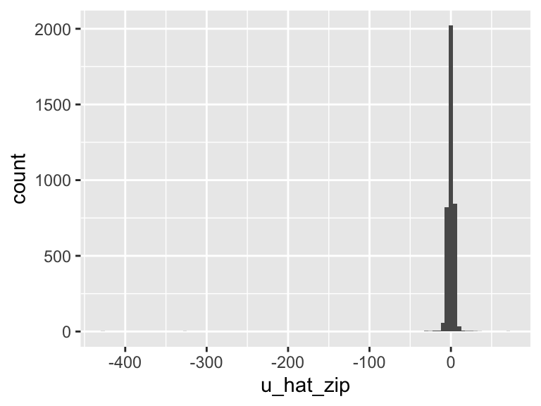

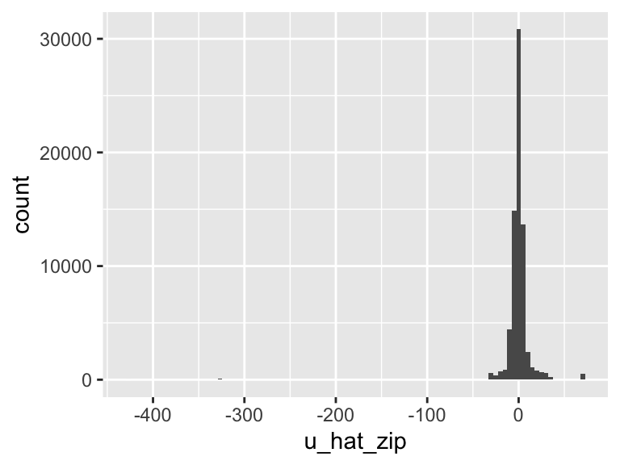

### Summary of the residuals

```
##      Min.   1st Qu.    Median      Mean   3rd Qu.      Max.
## -428.6449   -3.2994   -0.0889    0.0000    2.8842   68.8698
```